# Where Not to Get Lucky

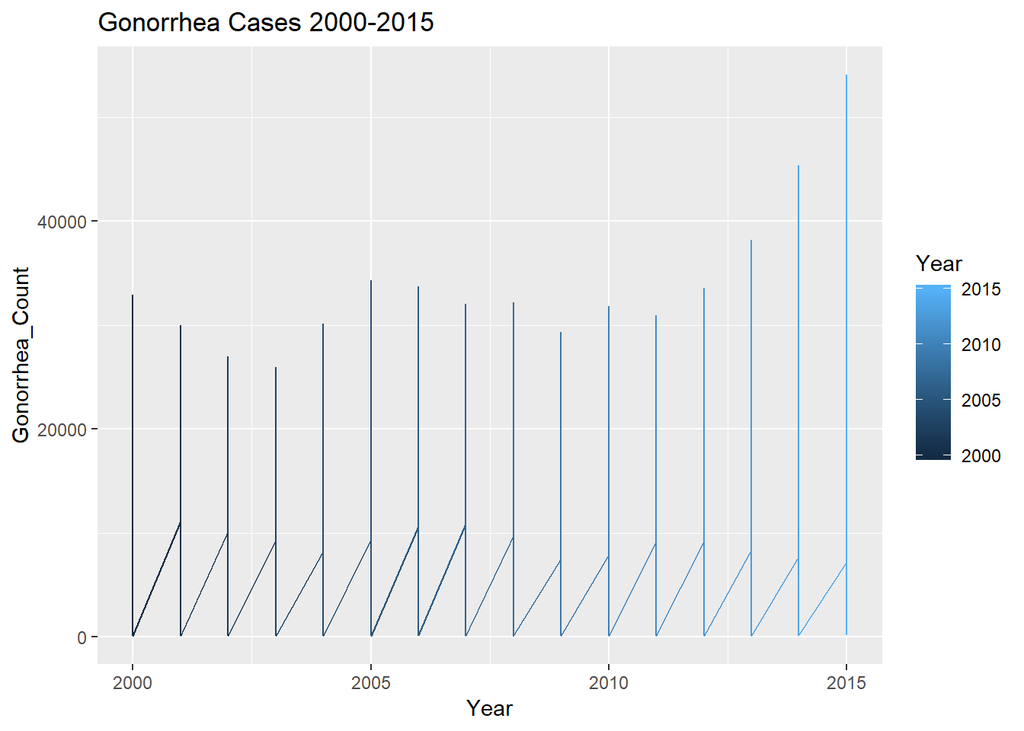

```r
ggplot(STDs_Nationally_Ranked_By_State, aes(x=Year, y= Gonorrhea_Count)) +        geom_line(aes(color=Year)) +
  labs(x= "Year", y = "Gonorrhea_Count", title= "Gonorrhea Cases 2000-2015")
```

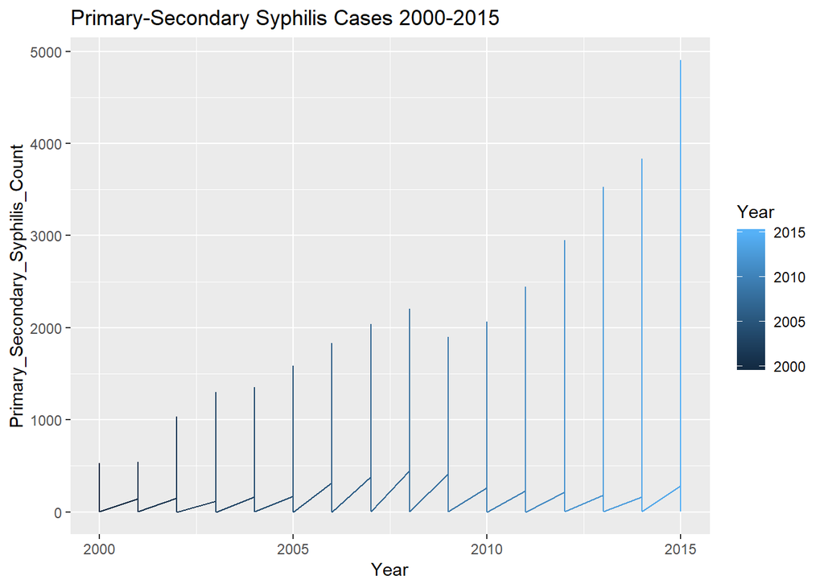

```r
ggplot(STDs_Nationally_Ranked_By_State, aes(x = Year,
  y =Primary_Secondary_Syphilis_Count)) +
  geom_line(aes(color=Year)) +
  labs(x = "Year", y = "Primary_Secondary_Syphilis_Count", title =        "Primary-Secondary Syphilis Cases 2000-2015")
```

```r
# Creating a new object for data manipulation

std_data<- (STDs_Nationally_Ranked_By_State)

# Reducing the data into chlyamidia, gonorrhea, and syphlis rates by year and state

std_data <- select (std_data,  c(Year, State, Chlamydia_Rate, Gonorrhea_Rate, Primary_Secondary_Syphilis_Rate))

# Transforming data into a tibble

as.tibble (std_data)
```

```
## # A tibble: 800 x 5
##     Year State     Chlamydia_Rate Gonorrhea_Rate Primary_Secondary_Syphili~
##    <int> <fct>              <dbl>          <dbl>                      <dbl>
##  1  2000 Alabama             344.          271                          2.8
##  2  2000 Alaska              409.           57.5                        0
##  3  2000 Arizona             244.           79.9                        3.7
##  4  2000 Arkansas            232.          136                          3.9
##  5  2000 Californ~           280.           63.6                        1
##  6  2000 Colorado            277.           71.9                        0.3
##  7  2000 Connecti~           223.           85.3                        0.5
##  8  2000 Delaware            363.          221.                         1.1
##  9  2000 Florida             208           142.                         2.6
## 10  2000 Georgia             356.          246.                         4.9
## # ... with 790 more rows
```

```r
# Observing the structure of the tibble

str (std_data)
```

```
## 'data.frame':    800 obs. of  5 variables:
##  $ Year                           : int  2000 2000 2000 2000 2000 2000 2000 2000 2000 2000 ...
##  $ State                          : Factor w/ 50 levels "Alabama","Alaska",..: 1 2 3 4 5 6 7 8 9 10 ...
##  $ Chlamydia_Rate                 : num  344 409 244 232 280 ...
##  $ Gonorrhea_Rate                 : num  271 57.5 79.9 136 63.6 ...
##  $ Primary_Secondary_Syphilis_Rate: num  2.8 0 3.7 3.9 1 0.3 0.5 1.1 2.6 4.9 ...
```

```r
glimpse (std_data)
```

```
## Observations: 800
## Variables: 5
## $ Year                            <int> 2000, 2000, 2000, 2000, 2000, ...
## $ State                           <fct> Alabama, Alaska, Arizona, Arka...
## $ Chlamydia_Rate                  <dbl> 344.2, 409.3, 243.7, 232.2, 28...
## $ Gonorrhea_Rate                  <dbl> 271.0, 57.5, 79.9, 136.0, 63.6...
## $ Primary_Secondary_Syphilis_Rate <dbl> 2.8, 0.0, 3.7, 3.9, 1.0, 0.3, ...
```

## Analysis

The data set will be modeled using regression and K-NN models to help determine relative model quality, based on lower RMSE scoring.

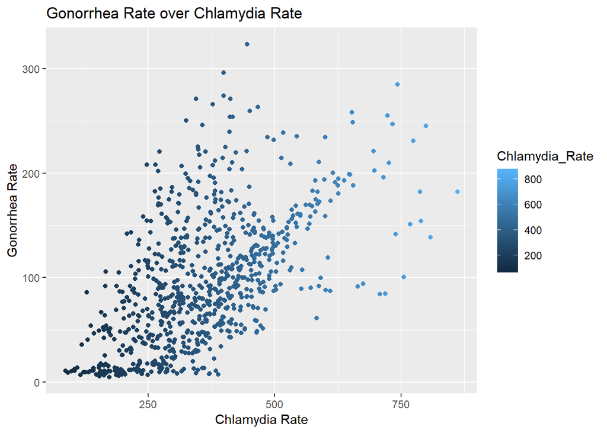

```r
# Regression modelling
# Code to create scatterplot between chlamydia and gonorrhea rates

ggplot(std_data, aes(x=Chlamydia_Rate, y=Gonorrhea_Rate)) +
geom_point(aes(color=Chlamydia_Rate)) +
labs(x= "Chlamydia Rate", y="Gonorrhea Rate", title = "Gonorrhea Rate over Chlamydia Rate")
```

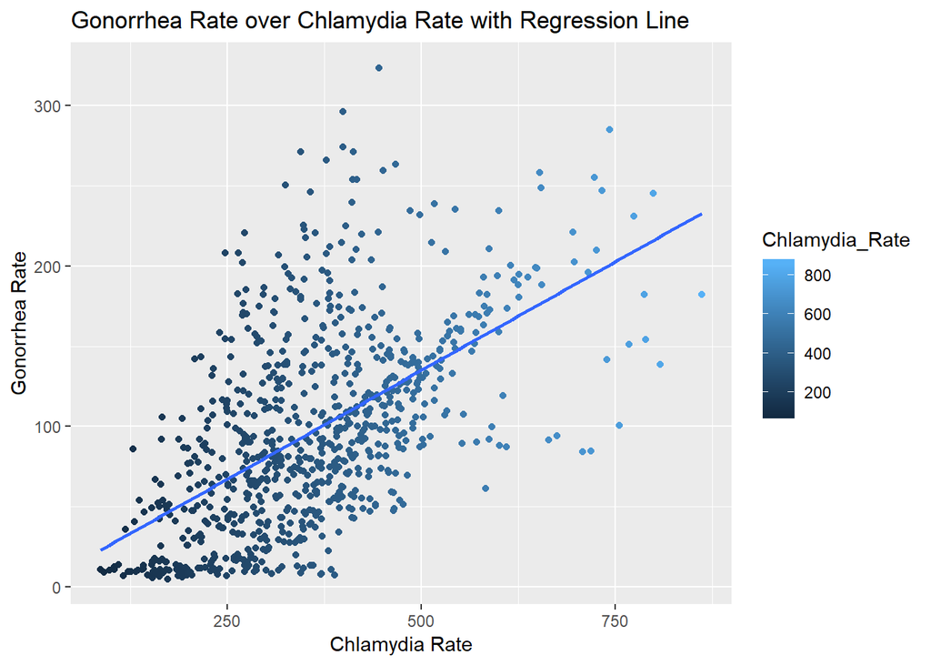

```r
# Add a best fitting line

ggplot(std_data, aes(x=Chlamydia_Rate, y=Gonorrhea_Rate)) +
geom_point(aes(color=Chlamydia_Rate)) +
labs(x= "Chlamydia Rate", y="Gonorrhea Rate", title = "Gonorrhea Rate over Chlamydia Rate with Regression Line") +
geom_smooth (method = "lm", se=FALSE)
```

```r
# Computing slope and intercept of regression model using formula of form y~x

model_std_data <- lm(Gonorrhea_Rate ~ Chlamydia_Rate, data=std_data)

# Output

model_std_data
```

```
##
## Call:
## lm(formula = Gonorrhea_Rate ~ Chlamydia_Rate, data = std_data)
##
## Coefficients:
##    (Intercept)  Chlamydia_Rate
##        -0.2493          0.2705
```

```r
# Output regression table using wrapper function

get_regression_table(model_std_data)
```

```
## # A tibble: 2 x 7
##   term           estimate std_error statistic p_value lower_ci upper_ci
##   <chr>             <dbl>     <dbl>     <dbl>   <dbl>    <dbl>    <dbl>
## 1 intercept        -0.249     5.34     -0.047   0.963  -10.7     10.2
## 2 Chlamydia_Rate    0.27      0.014    19.4     0        0.243    0.298
```

```r
# Multiple regression adding syphilis rate to previous model

# Fit model

model2_std_data <- lm(Gonorrhea_Rate ~ Chlamydia_Rate + Primary_Secondary_Syphilis_Rate, data=std_data)

# Output multiple regression model

model2_std_data
```

```
##
## Call:
## lm(formula = Gonorrhea_Rate ~ Chlamydia_Rate + Primary_Secondary_Syphilis_Rate,
##     data = std_data)
##
## Coefficients:
##                     (Intercept)                   Chlamydia_Rate
##                           6.991                            0.197
## Primary_Secondary_Syphilis_Rate
##                           6.578
```

```r
# Get regression table
get_regression_table(model2_std_data)
```

```
## # A tibble: 3 x 7
##   term               estimate std_error statistic p_value lower_ci upper_ci
##   <chr>                 <dbl>     <dbl>     <dbl>   <dbl>    <dbl>    <dbl>
## 1 intercept             6.99      5.19       1.35   0.179   -3.20    17.2
## 2 Chlamydia_Rate        0.197     0.016     12.3    0        0.166    0.228
## 3 Primary_Secondary~    6.58      0.788      8.35   0        5.03     8.12
```

```r
# Sum, calculate the mean of US chlamydia, gonorrhea, and syphilis rates

model3_std_data <- mutate (std_data, Total_Mean=((Chlamydia_Rate + Gonorrhea_Rate + Primary_Secondary_Syphilis_Rate)/3))

# Correlation between Total_Mean and chlamydia, gonorrhea, and syphilis rates

model3_std_data %>%
  summarize(correlation = cor(Chlamydia_Rate, Total_Mean))
```

```
##   correlation
## 1   0.9546932
```

```r
model3_std_data %>%
  summarize(correlation = cor(Gonorrhea_Rate, Total_Mean))
```

```
##   correlation
## 1   0.7851987
```

```r
model3_std_data %>%
  summarize(correlation = cor(Primary_Secondary_Syphilis_Rate, Total_Mean))
```

```
##   correlation
## 1   0.6041468
```

```r
# Arrange data from highest ranked states to lowest

arrange(model3_std_data, desc(Total_Mean))
```

```
##     Year          State Chlamydia_Rate Gonorrhea_Rate
## 1   2009    Mississippi          799.1          245.3
## 2   2010         Alaska          861.7          182.3
## 3   2007    Mississippi          743.0          284.8
## 4   2012    Mississippi          774.0          230.8
## 5   2008    Mississippi          723.2          255.0
## 6   2005    Mississippi          732.6          247.0
## 7   2014         Alaska          787.5          182.4
## 8   2011         Alaska          808.0          138.5
## 9   2013         Alaska          789.4          154.2
## 10  2010    Mississippi          725.5          209.9
## 11  2015      Louisiana          695.2          221.1
## 12  2015         Alaska          768.3          151.1
## 13  2011    Mississippi          715.0          195.9
## 14  2006    Mississippi          652.9          258.1
```

[output cut: 1587 more lines]

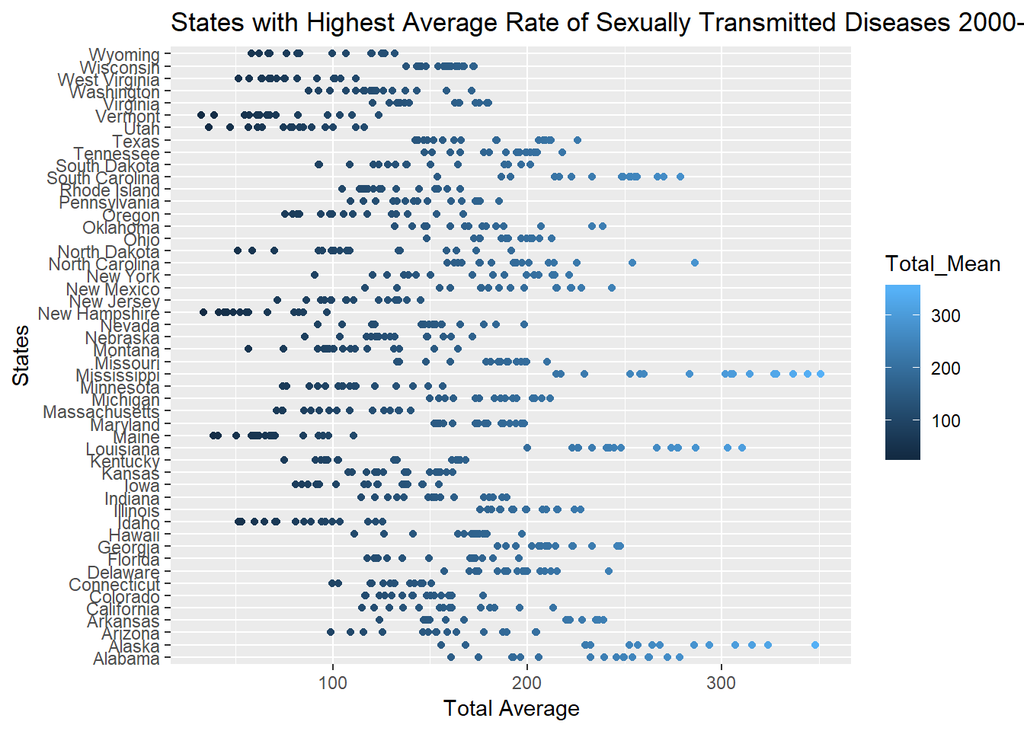

```r
# Visualize the model

ggplot(model3_std_data, aes(x=Total_Mean, y=State)) + geom_point(aes(color=Total_Mean)) + labs(x= "Total Average", y="States", title = "States with Highest Average Rate of Sexually Transmitted Diseases 2000-2015")
```

```r
summary(model3_std_data)
```

```
##       Year             State     Chlamydia_Rate  Gonorrhea_Rate
##  Min.   :2000   Alabama   : 16   Min.   : 86.2   Min.   :  5.00
##  1st Qu.:2004   Alaska    : 16   1st Qu.:272.2   1st Qu.: 49.30
##  Median :2008   Arizona   : 16   Median :350.6   Median : 90.40
##  Mean   :2008   Arkansas  : 16   Mean   :360.0   Mean   : 97.13
##  3rd Qu.:2011   California: 16   3rd Qu.:433.6   3rd Qu.:138.05
##  Max.   :2015   Colorado  : 16   Max.   :861.7   Max.   :323.50
##                 (Other)   :704
##  Primary_Secondary_Syphilis_Rate   Total_Mean
##  Min.   : 0.000                  Min.   : 32.3
##  1st Qu.: 0.900                  1st Qu.:114.5
##  Median : 2.300                  Median :150.5
##  Mean   : 2.919                  Mean   :153.4
##  3rd Qu.: 4.200                  3rd Qu.:188.6
##  Max.   :16.500                  Max.   :350.8
##
```

```r
# Reduce data to states with the very highest rates of sexually transmitted diseases, eliminating rates for chlymidia, gonorrhea, and syphilis

highest_states <- select (model3_std_data, "State", "Total_Mean", "Year")

# Correlation between Total_Mean and year

highest_states %>%
  summarize(correlation = cor(Year, Total_Mean))
```

```
##   correlation
## 1   0.3898846
```

```r
# Arrange highest states of STDs

arrange (highest_states, desc(Total_Mean))
```

```
##              State Total_Mean Year
## 1      Mississippi  350.80000 2009
## 2           Alaska  348.13333 2010
## 3      Mississippi  344.13333 2007
## 4      Mississippi  336.60000 2012
## 5      Mississippi  328.16667 2008
## 6      Mississippi  327.10000 2005
## 7           Alaska  323.96667 2014
## 8           Alaska  315.73333 2011
## 9           Alaska  315.56667 2013
## 10     Mississippi  314.36667 2010
## 11       Louisiana  310.43333 2015
## 12          Alaska  306.83333 2015
## 13     Mississippi  305.76667 2011
## 14     Mississippi  304.66667 2006
```

[output cut: 786 more lines]

```r
# Summarize new data set

summary (highest_states)
```

```
##         State       Total_Mean         Year
##  Alabama   : 16   Min.   : 32.3   Min.   :2000
##  Alaska    : 16   1st Qu.:114.5   1st Qu.:2004
##  Arizona   : 16   Median :150.5   Median :2008
##  Arkansas  : 16   Mean   :153.4   Mean   :2008
##  California: 16   3rd Qu.:188.6   3rd Qu.:2011
##  Colorado  : 16   Max.   :350.8   Max.   :2015
##  (Other)   :704
```

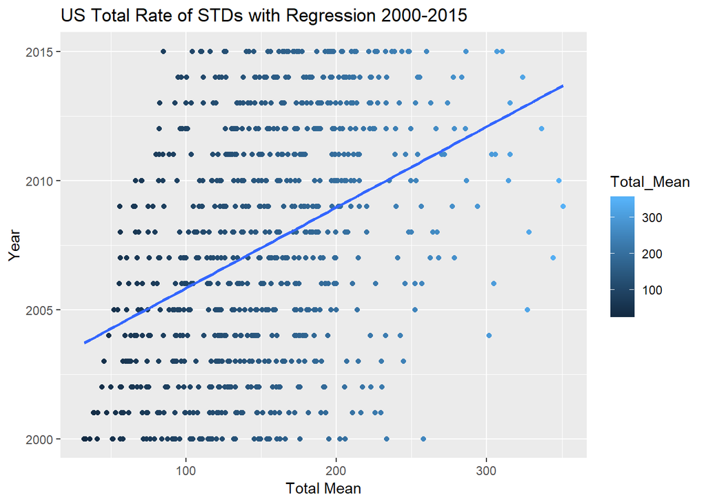

```r
# Plot US STDs 2000-2015 with regression line
ggplot(highest_states, aes(x=Total_Mean, y=Year)) +
geom_point(aes(color=Total_Mean)) +
labs(x= "Total Mean", y="Year", title = "US Total Rate of STDs with Regression 2000-2015") +
geom_smooth (method = "lm", se=FALSE)
```

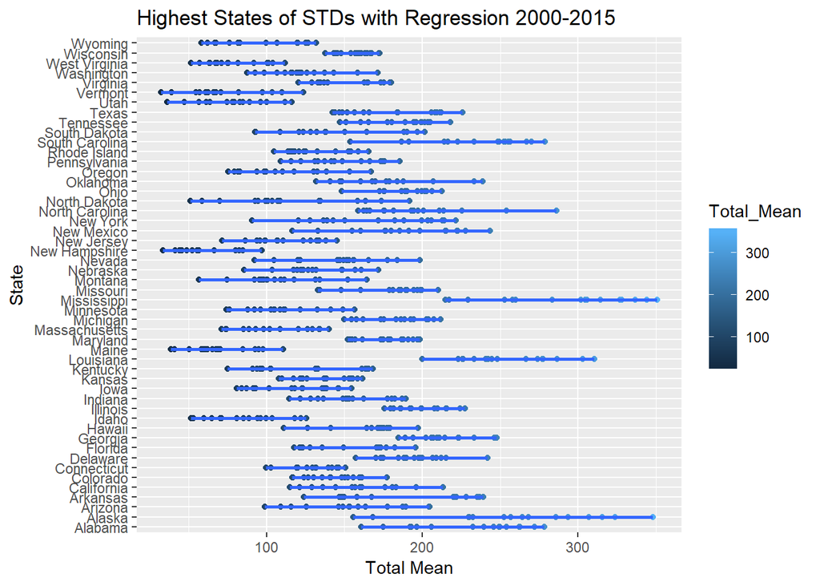

```r
# Plot states with highest rates of STDs 2000-2015 with regression line
ggplot(highest_states, aes(x=Total_Mean, y=State)) +
geom_point(aes(color=Total_Mean)) +
labs(x= "Total Mean", y="State", title = "Highest States of STDs with Regression 2000-2015") +
geom_smooth (method = "lm", se=FALSE)
```

```r
# Computing slope and intercept of regression model using formula of form y~x

highest_states <- lm(Total_Mean ~ State, highest_states)


# Regression table of states with highest rates of STDs 2000-2015

get_regression_table(highest_states)
```

```
## # A tibble: 50 x 7
##    term             estimate std_error statistic p_value lower_ci upper_ci
##    <chr>               <dbl>     <dbl>     <dbl>   <dbl>    <dbl>    <dbl>
##  1 intercept           229.       6.92     33.1    0        216.    243.
##  2 StateAlaska          36.2      9.79      3.70   0         17.0    55.4
##  3 StateArizona        -76.0      9.79     -7.76   0        -95.2   -56.8
##  4 StateArkansas       -39.9      9.79     -4.08   0        -59.1   -20.7
##  5 StateCalifornia     -70.4      9.79     -7.19   0        -89.7   -51.2
##  6 StateColorado       -85.8      9.79     -8.77   0       -105.    -66.6
##  7 StateConnecticut    -97.0      9.79     -9.90   0       -116.    -77.7
##  8 StateDelaware       -34.7      9.79     -3.54   0        -53.9   -15.5
##  9 StateFlorida        -77.3      9.79     -7.89   0        -96.5   -58.1
## 10 StateGeorgia        -16.4      9.79     -1.67   0.095    -35.6     2.87
## # ... with 40 more rows
```

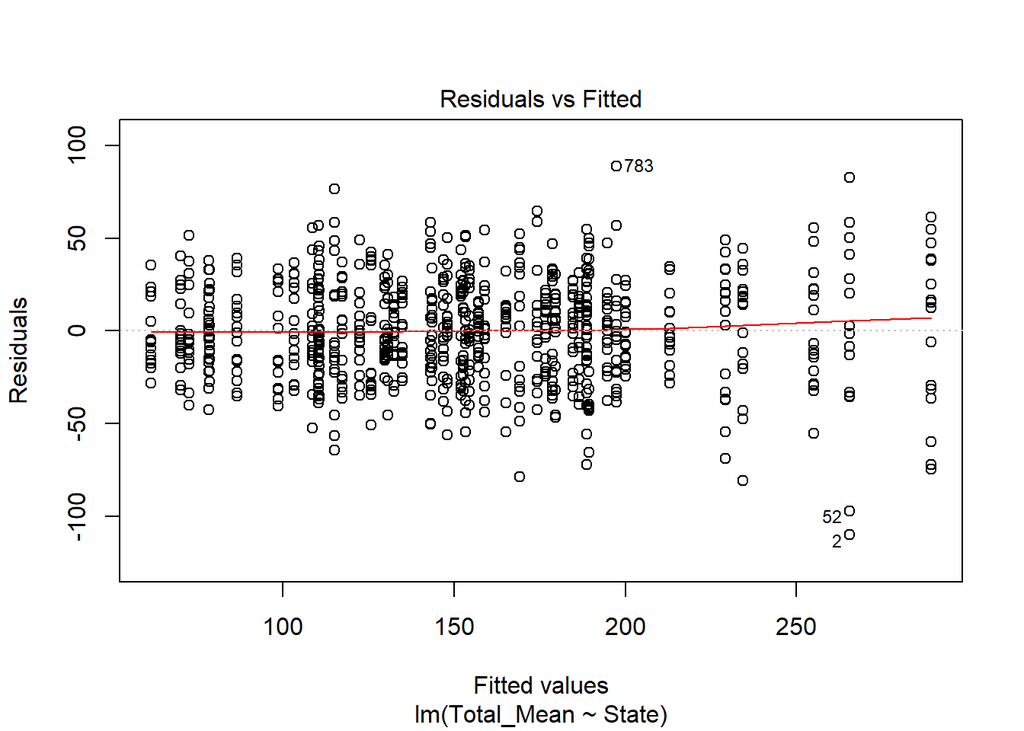

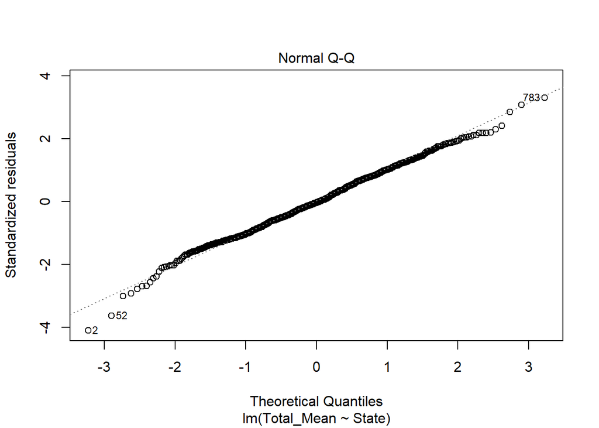

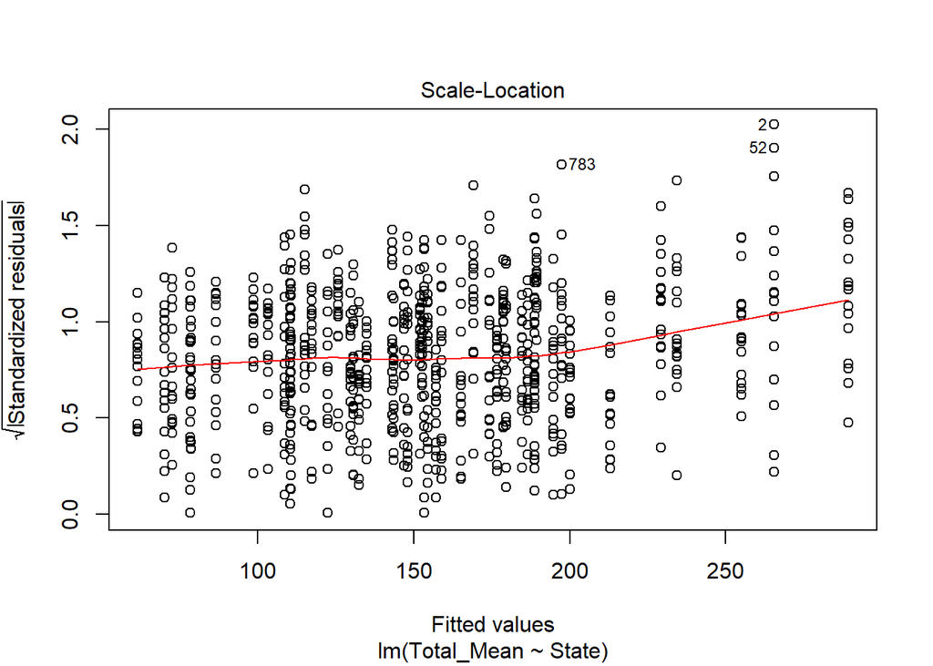

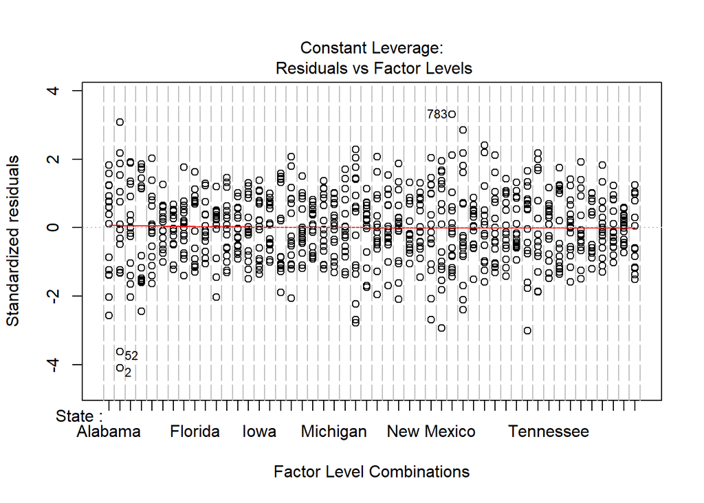

```r
# Plot

plot(highest_states)
```

```r
# Get all fitted/predicted values/residuals

get_regression_points(highest_states)
```

```
## # A tibble: 800 x 5
##       ID Total_Mean State       Total_Mean_hat residual
##    <int>      <dbl> <fct>                <dbl>    <dbl>
##  1     1       206  Alabama               229.  -23.4
##  2     2       156. Alaska                266. -110.
##  3     3       109. Arizona               153.  -44.2
##  4     4       124. Arkansas              189.  -65.4
##  5     5       115. California            159.  -43.9
##  6     6       116. Colorado              144.  -27.0
##  7     7       103. Connecticut           132.  -29.5
##  8     8       195. Delaware              195.    0.285
##  9     9       118. Florida               152.  -34.6
## 10    10       202. Georgia               213.  -10.5
## # ... with 790 more rows
```

```r
# Prepare data to be plotted

model_highest_states <- get_regression_points(highest_states)

# Calculate sum of squared residuals

get_regression_points(highest_states) %>%
  mutate(sq_residuals = residual^2) %>%
  summarize(sum_sq_residuals = sum(sq_residuals))
```

```
## # A tibble: 1 x 1
##   sum_sq_residuals
##              <dbl>
## 1          575090.
```

```r
# Calculate mean squared error: use mean() instead of sum()

get_regression_points(highest_states) %>%
  mutate(sq_residuals = residual^2) %>%
  summarize(mse = mean (sq_residuals))
```

```
## # A tibble: 1 x 1
##     mse
##   <dbl>
## 1  719.
```

```r
# Calculate root mean squared error

get_regression_points(highest_states) %>%
  mutate(sq_residuals = residual^2) %>%
  summarize(mse = mean (sq_residuals))  %>%
  mutate(rmse = sqrt(mse))
```

```
## # A tibble: 1 x 2
##     mse  rmse
##   <dbl> <dbl>
## 1  719.  26.8
```

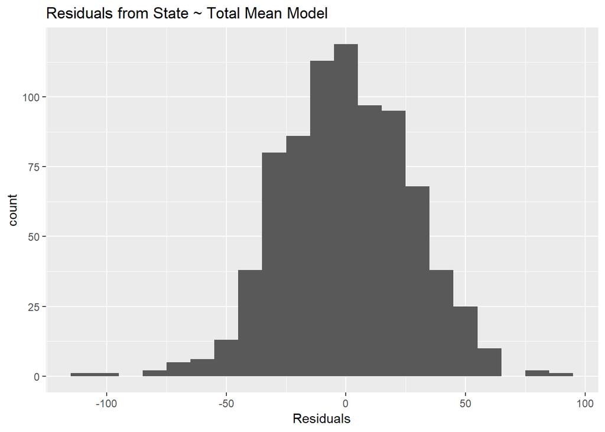

```r
# Plot residuals

ggplot(model_highest_states, aes(x = residual)) +
  geom_histogram(binwidth=10) +
  labs(x = "Residuals", title = "Residuals from State ~ Total Mean Model")
```

## Cross validation of set prediction framework

```r
set.seed(2)

# Randomly shuffle order of rows:
stds_shuffled <- model3_std_data %>%
  sample_frac(size = 1, replace = FALSE)
# Split into train and test:
train <- stds_shuffled %>%
  slice(1:400)
test <- stds_shuffled %>%
  slice(401:800)

# Training models on training data
train_stds_shuffled <- lm(Total_Mean ~ State + Chlamydia_Rate,
data = train)

get_regression_table(train_stds_shuffled)
```

```
## # A tibble: 51 x 7
##    term             estimate std_error statistic p_value lower_ci upper_ci
##    <chr>               <dbl>     <dbl>     <dbl>   <dbl>    <dbl>    <dbl>
##  1 intercept           70.0       3.42     20.5    0         63.3    76.7
##  2 StateAlaska        -24.3       3.88     -6.25   0        -31.9   -16.6
##  3 StateArizona       -42.1       4.03    -10.5    0        -50.0   -34.2
##  4 StateArkansas      -14.7       3.31     -4.45   0        -21.2    -8.22
##  5 StateCalifornia    -34.8       3.37    -10.3    0        -41.5   -28.2
##  6 StateColorado      -45.6       3.41    -13.4    0        -52.3   -38.9
##  7 StateConnecticut   -43.1       4.33     -9.94   0        -51.6   -34.6
##  8 StateDelaware      -18.6       3.42     -5.45   0        -25.4   -11.9
##  9 StateFlorida       -26.7       3.32     -8.04   0        -33.2   -20.1
## 10 StateGeorgia        -6.00      3.43     -1.75   0.081    -12.7     0.75
## # ... with 41 more rows
```

```r
## Making predictions on test data

# Train model on train:

train_stds_shuffled <- lm(Total_Mean ~ State + Chlamydia_Rate,
data = train)

# Get predictions on test:

get_regression_points(train_stds_shuffled, newdata = test)
```

```
## # A tibble: 400 x 6
##       ID Total_Mean State      Chlamydia_Rate Total_Mean_hat residual
##    <int>      <dbl> <fct>               <dbl>          <dbl>    <dbl>
##  1     1      112.  Washington           288.          117.     -5.16
##  2     2      146.  Nevada               298.          131.     14.8
##  3     3       53.0 Idaho                153.           54.4    -1.38
##  4     4      180.  New Mexico           467.          182.     -1.78
##  5     5      194.  Missouri             454.          200.     -5.98
##  6     6      199.  New Mexico           503.          194.      4.95
##  7     7      143.  Washington           362.          142.      1.52
##  8     8      152.  Montana              413           145.      7.60
##  9     9      205.  Arizona              489.          189.     15.8
## 10    10      121.  Kansas               283.          126.     -4.60
## # ... with 390 more rows
```

```r
## Assessing predictions with RMSE
# Train model:
train_stds_shuffled <- lm(Total_Mean ~ State + Chlamydia_Rate, data = train)

# Get predictions and compute RMSE:
get_regression_points(train_stds_shuffled, newdata = test) %>%
  mutate(sq_residuals = residual^2) %>%
  summarize(rmse = sqrt(mean(sq_residuals)))
```

```
## # A tibble: 1 x 1
##    rmse
##   <dbl>
## 1  7.55
```

```r
# Comparing RMSE
# Train model:
train_stds_shuffled_2 <- lm(Total_Mean ~ State + Gonorrhea_Rate, data = train)

# Get predictions and compute RMSE:
get_regression_points(train_stds_shuffled_2, newdata = test) %>%
  mutate(sq_residuals = residual^2) %>%
  summarize(rmse = sqrt(mean(sq_residuals)))
```

```
## # A tibble: 1 x 1
##    rmse
##   <dbl>
## 1  29.0
```

```r
# Additional models
# k-NN

set.seed(2)

mod <- train(Total_Mean ~ ., data =stds_shuffled, method = "knn",tuneLength = 12)

# Observing the structure of the model

str(mod)
```

[output not shown]

[output cut: 169 more lines]

[output not shown]

```r
head(mod)
```

[output not shown]

[output cut: 51 more lines]

[output not shown]

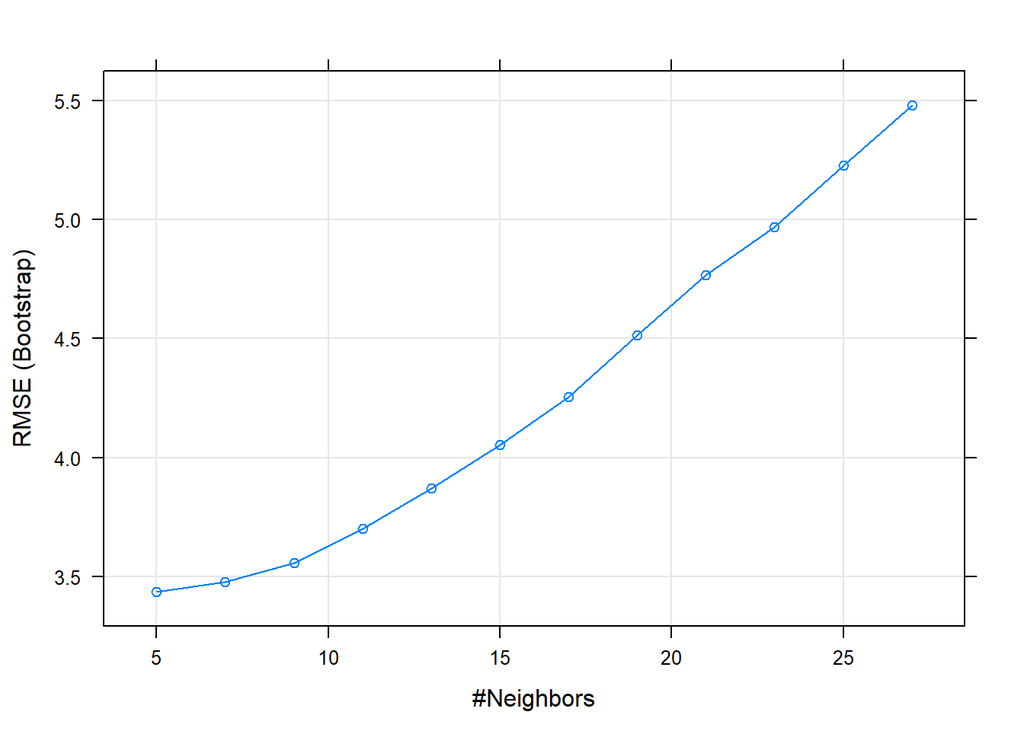

```r
# Visulaizing the k-NN model

plot(mod)
```

## Results

Intial analysis of the data showed an increase in all sexually transmitted diseases studied between 2000-2015. Of the models utilized in this project, the k-NN model yielded a RMSE value of 3.43 versus 7.55 for standard regression with rate of chlamydia as a predictor.

## Conclusion

Initial data analysis clearly indicated that rates of chlamydia, gonorrhea and syphilis, increased considerably from 2000-2015.

Regression modeling and calculating the RMSE (root means squared) outcomes, indicated that chlamydia rates were better at predicting total mean rates versus gonorrhea rates.

k-NN modeling provided lower RMSE values than standard regression.